# FIT5147 DEP S2 2022 - 32980523

# FIT5147 | Data Exploration Project

## Study of Airbnb User Preferences in Chile and Australia

> The objective is to provide an easy to follow framework for analysis that allows the analyst or PhD student to walk through their entire approach in a step-by-step manner with their colleagues or PhD supervisors.

> In each of the 6-steps, the researcher is to provide their code, outputs for the code, and any comments/thoughts that may help the reader interpret the approach that was taken.

## **1. Introduction**

For this study I’ve chosen two cities that I’m highly familiar with: **Santiago de Chile**, where I lived most of my life up until the age of 26; and **Melbourne, Australia** where I’ve lived for the past 7 years. Both of this cities are upwards of 5 million people and are visited by thousand of tourists every year.

### 1.1 Research Question 1: Features of popularity on each city in the study

> What are some of the common features of popular listings in the cities included in the study? For example, can we see clusters of popularity in certain areas of the city that are near the CBD or near bars and restaurants?

#### Hypothesis

Popular listings in metropolitan cities are close to entertainment hubs (pubs and restaurants) and the CBD area. Smaller cities such as Hobart or Byron Bay present a similar pattern, but they also base their popularity on closeness to beaches and national parks.

Popular listings also rely on the type of amenities provided in the accommodation such as wi-fi, number of bathrooms, etc.

#### Potential Issues or Challenges

It’s possible that each listing’s popularity may be based on specific qualitative characteristics that and that are problematic to measure. For example, it would be difficult to incorporate the ‘word of mouth’ impact of Airbnb users picking one area over another one, or to measure how many customers pick a listing for random reasons such as convenience to them specifically (i.e. listing close to a relative).

### 1.2 Research Question 2: Common features of popular listings across cities in the study

> Are there any significant differences on these features across Santiago and Melbourne suburbs? For example, are the popular areas in Santiago more concentrated compared to Melbourne?

#### Hypothesis

Melbourne and Santiago are unlike each other in many respects. Melbourne’s suburbs are reasonably self-contained with amenities and entertainment in walking distance, while Santiago is a more spread out city with less number of hubs per suburb. Therefore, more clusters of popularity would be expected to be seen in Santiago than Melbourne.

On the other hand, there should be evidence around popular listing characteristics that are independent of location.

#### Potential Issues or Challenges

Comparing cities that are vastly different in demographics could introduce noise into the results…

### 1.4 Environment Setup

The following packages will be used for this project:

Selected libraries

| Package name | Category |
| --- | --- |
| `tidyverse` | General Data Analysis |
| `dplyr` | General data analysis |
| `broom` | Geo-spatial Analysis |
| `ggmap` | Geo-spatial Analysis |
| `mapproj` | Geo-spatial Analysis |
| `geogjsonio` | Geo-spatial Analysis |
| `ggmap` | Geo-spatial Analysis |
| `ggplot2` | General visualizations |
| `janitor` | Data Cleaning |
| `naniar` | Data Cleaning |
| `UpSetR` | Data Cleaning |

## **2. Data Collection and Measurement Strategy (Data Wrangling - Data Checking)**

### 2.1 Description of the data

The data set contains information from [Inside Airbnb](http://insideairbnb.com/get-the-data/) about four different regions:

1. Melbourne, Australia (best city in the world)
2. Northern Rivers, Australia (land of Byron Bay and other wonders)
3. Tasmania, Australia (the island of the island)
4. Santiago, Chile (hometown of the author of this report)

We will also use *four sets* of quarterly produced data for each one of the regions, in order to explore time-wise variability of the listings.

A summary of all the information is provided in the table below:

[output not shown]

### 2.2 Data Loading

The following steps will go through loading the data that will be used throughout the project.

#### 2.2.1 Listings

```r
# combine data sets
all.listings <- list.files(recursive = TRUE, pattern="^listings.csv.gz$") %>%
  map_df(~read_csv(.,show_col_types = FALSE))
```

#### 2.2.2 Reviews

```r
# combine data sets
all.reviews <- list.files(recursive = TRUE, pattern="^reviews.csv.gz$") %>%
  map_df(~read_csv(.,show_col_types = FALSE))
```

#### 2.2.3 Calendar

```r
# combine data sets
# all.calendar <- list.files(recursive = TRUE, pattern="^calendar.csv.gz$") %>%
#   map_df(~read_csv(.,show_col_types = FALSE))
```

### 2.3 Data Cleaning

#### 2.3.1 Data Cleaning: Duplicates

- First, we will check for duplicates on each data frame, by using `get_dupes` function from the `janitor` library:

```r
#check listing duplicates
listings.dupes <- get_dupes(all.listings, id, last_scraped)
```

```
No duplicate combinations found of: id, last_scraped
```

```r
#check reviews duplicates
review.dupes <- get_dupes(all.reviews,-c(comments,reviewer_name))
```

```r
head(review.dupes)
```

[output not shown]

```r
#run later
# calendar.dupes <- get_dupes(all.reviews,-c(comments,reviewer_name))
```

- removed the duplicates reviews

```r
#remove duplicated reviews
# fix later
all.reviews <- all.reviews %>% distinct_at(vars(-comments,-reviewer_name))
```

#### 2.3.2 Data Cleaning: Missing Values

We will use the fantastic tools from the `naniar` summarize issues with missing values:

```r
all.listings %>%
  miss_var_summary() %>%
  filter(pct_miss >20)
```

| variable | n_miss | pct_miss |
| --- | --- | --- |
| neighbourhood_group_cleansed | 150123 | 100.00000 |
| bathrooms | 150123 | 100.00000 |
| calendar_updated | 150123 | 100.00000 |
| license | 117031 | 77.95674 |
| host_neighbourhood | 110697 | 73.73754 |
| host_about | 65881 | 43.88468 |
| neighborhood_overview | 56316 | 37.51324 |
| neighbourhood | 56316 | 37.51324 |
| review_scores_location | 35040 | 23.34086 |
| review_scores_checkin | 35038 | 23.33953 |

[output cut: 8 more lines]

```r
all.reviews %>%
  miss_var_summary()
```

| variable | n_miss | pct_miss |
| --- | --- | --- |
| listing_id | 0 | 0 |
| id | 0 | 0 |
| date | 0 | 0 |
| reviewer_id | 0 | 0 |

#### 2.3.3 Data Cleaning: Preparation of new Variables

- Remove unnecessary variables

```r
all.listings.clean <- all.listings %>%
  select(-listing_url, -scrape_id, -neighborhood_overview, -picture_url, -host_id, -host_url, -host_name, -host_location,
         -host_thumbnail_url, -host_picture_url, -first_review, -last_review, -calendar_last_scraped,
         -has_availability, -host_has_profile_pic, -calendar_updated, -license, -bathrooms, -neighbourhood, -host_neighbourhood, -neighbourhood_group_cleansed)
```

- Rename names of lengthy features

```r
#rename some annoyingly long columns names
all.listings.clean <- all.listings.clean %>% rename(nb_cleansed = neighbourhood_cleansed)
```

- Connect a list of neighborhood by city to the main listing data

```r
nb.list <- read_csv("data/neighbourhoods.csv", show_col_types = FALSE)

all.listings.clean <- all.listings.clean %>% left_join(nb.list, by=c("nb_cleansed" = "neighbourhood_cleansed"))
```

- Correct any data type in the `all.listings` data frame that may not be fit for analysis, and at this stage it’s only the `price` variable:

```r
#using parse_number to fix price data type
all.listings.clean$price <- parse_number(all.listings.clean$price)
```

- And remove listings with price equal to zero or negative values (6 listings)

```r
all.listings.clean %>% filter(price == 0)
```

| id | last_scraped | name | description | host_since | host_about | host_response_time | host_response_rate | host_acceptance_rate | host_is_superhost | host_listings_count | host_total_listings_count | host_verifications | host_identity_verified | nb_cleansed | latitude | longitude | property_type | room_type | accommodates | bathrooms_text | bedrooms | beds | amenities | price | minimum_nights | maximum_nights | minimum_minimum_nights | maximum_minimum_nights | minimum_maximum_nights | … |
| --- | --- | --- | --- | --- | --- | --- | --- | --- | --- | --- | --- | --- | --- | --- | --- | --- | --- | --- | --- | --- | --- | --- | --- | --- | --- | --- | --- | --- | --- | --- |
| 41278626 | 2021-09-08 | Free bushfire accommodation for family in need | NA | 2018-02-28 | NA | N/A | N/A | N/A | FALSE | 1 | 1 | ['email', 'phone'] | FALSE | Yarra Ranges | -37.78599 | 145.38469 | Private room in residential home | Private room | 4 | 1 private bath | 2 | 2 | ["Essentials", "Dryer", "Hair dryer", "Washer", "Hot water", "Smoke alarm", "Shampoo", "Air conditioning", "Heating", "Dedicated workspace", "Iron", "Kitchen", "Long term stays allowed", "Wifi", "Free… | 0 | 1 | 1125 | 1 | 1 | 1125 | … |
| 41278626 | 2021-12-07 | Free bushfire accommodation for family in need | NA | 2018-02-28 | NA | N/A | N/A | N/A | FALSE | 1 | 1 | ['email', 'phone'] | FALSE | Yarra Ranges | -37.78599 | 145.38469 | Private room in residential home | Private room | 4 | 1 private bath | 2 | 2 | ["Smoke alarm", "Long term stays allowed", "Hair dryer", "Kitchen", "Hot water", "Dedicated workspace", "Essentials", "Shampoo", "Heating", "Iron", "Wifi", "Air conditioning", "Dryer", "Free parking o… | 0 | 1 | 1125 | 1 | 1 | 1125 | … |
| 41278626 | 2022-03-31 | Free bushfire accommodation for family in need | NA | 2018-02-28 | NA | N/A | N/A | N/A | FALSE | 1 | 1 | ['email', 'phone'] | FALSE | Yarra Ranges | -37.78599 | 145.38469 | Private room in home | Private room | 4 | 1 private bath | 2 | 2 | ["Smoke alarm", "Long term stays allowed", "Essentials", "TV", "Hot water", "Dryer", "Washer", "Heating", "Shampoo", "Dedicated workspace", "Kitchen", "Free parking on premises", "Air conditioning", "… | 0 | 1 | 1125 | 1 | 1 | 1125 | … |
| 41278626 | 2022-06-06 | Free bushfire accommodation for family in need | NA | 2018-02-28 | NA | N/A | N/A | N/A | FALSE | 1 | 1 | ['email', 'phone'] | FALSE | Yarra Ranges | -37.78599 | 145.38469 | Private room in home | Private room | 4 | 1 private bath | 2 | 2 | ["TV", "Long term stays allowed", "Hair dryer", "Wifi", "Kitchen", "Air conditioning", "Washer", "Shampoo", "Iron", "Free parking on premises", "Heating", "Smoke alarm", "Dryer", "Essentials", "Hot wa… | 0 | 1 | 1125 | 1 | 1 | 1125 | … |
| 43205350 | 2021-09-28 | Boulevard Suites Ferrat | NA | 2020-04-16 | NA | N/A | N/A | N/A | FALSE | 0 | 0 | ['email', 'phone', 'work_email'] | FALSE | Las Condes | -33.39981 | -70.57459 | Room in boutique hotel | Hotel room | 0 | NA | NA | NA | ["Free wifi", "Dedicated workspace", "Complimentary breakfast", "Room service", "Housekeeping", "Long term stays allowed", "Laundry services", "Complimentary self parking", "Pets allowed", " toiletrie… | 0 | 1 | 28 | 1 | 1 | 28 | … |
| 43205350 | 2021-12-25 | Boulevard Suites Ferrat | NA | 2020-04-16 | NA | a few days or more | 0% | 0% | FALSE | 0 | 0 | ['email', 'phone', 'work_email'] | FALSE | Las Condes | -33.39981 | -70.57459 | Room in boutique hotel | Hotel room | 0 | NA | NA | NA | ["Complimentary self parking", "Housekeeping", "Complimentary breakfast", " toiletries", "Long term stays allowed", "Laundry services", "Room service", "Dedicated workspace", "Pets allowed", "Free wif… | 0 | 1 | 28 | 1 | 1 | 28 | … |

```r
all.listings.clean %>% filter(price < 0)
```

| id | last_scraped | name | description | host_since | host_about | host_response_time | host_response_rate | host_acceptance_rate | host_is_superhost | host_listings_count | host_total_listings_count | host_verifications | host_identity_verified | nb_cleansed | latitude | longitude | property_type | room_type | accommodates | bathrooms_text | bedrooms | beds | amenities | price | minimum_nights | maximum_nights | minimum_minimum_nights | maximum_minimum_nights | minimum_maximum_nights | … |
| --- | --- | --- | --- | --- | --- | --- | --- | --- | --- | --- | --- | --- | --- | --- | --- | --- | --- | --- | --- | --- | --- | --- | --- | --- | --- | --- | --- | --- | --- | --- |

```r
all.listings.clean <- all.listings.clean %>% filter(price!=0)
```

- Correct name caps

Also, some of the neighborhood names are incorrectly formatted:

```r
#fixing capitalised words
#check later, as it may get in the way with joins
all.listings.clean$nb_cleansed <- str_to_title(all.listings.clean$nb_cleansed)
```

- Reformat scraped data

```r
# reformat scraping dates
all.listings.clean$last_scraped.new <- format(all.listings.clean$last_scraped,'%b-%Y')
```

```r
# replace amenities textual variable with count of amenities
all.listings.clean <- all.listings.clean %>%
  mutate(amenities_count = sapply(str_split(amenities, ","), length)) %>%
  select(-amenities)
```

[output not shown]

- Create binned variable for ratings

```r
# 1.6 Create binned variable for ratings
all.listings.clean$rating.bin <- cut(all.listings.clean$review_scores_rating, c(0,1,2,3,4,5))
```

- Improve property type variable

```r
# get actual property type (remove room type component) from property_type
all.listings.clean <- all.listings.clean %>%
  mutate(property_type = tolower(property_type)) %>%
  mutate(property_type = case_when(
    grepl(" in ", property_type, fixed = TRUE) == TRUE ~ gsub("^.*in ", "", property_type),
    TRUE ~ gsub("entire ", "", property_type)
  ))
```

- Finally, factorize all character and logical variables for later processing.

```r
all.listings.final <- all.listings.clean %>%
  mutate(across(where(is.character), as.factor)) %>%
  mutate(across(where(is.logical), as.factor))
```

## **Step 3: Visualize & Summarize Data**

### 3.1 Univariate Analysis

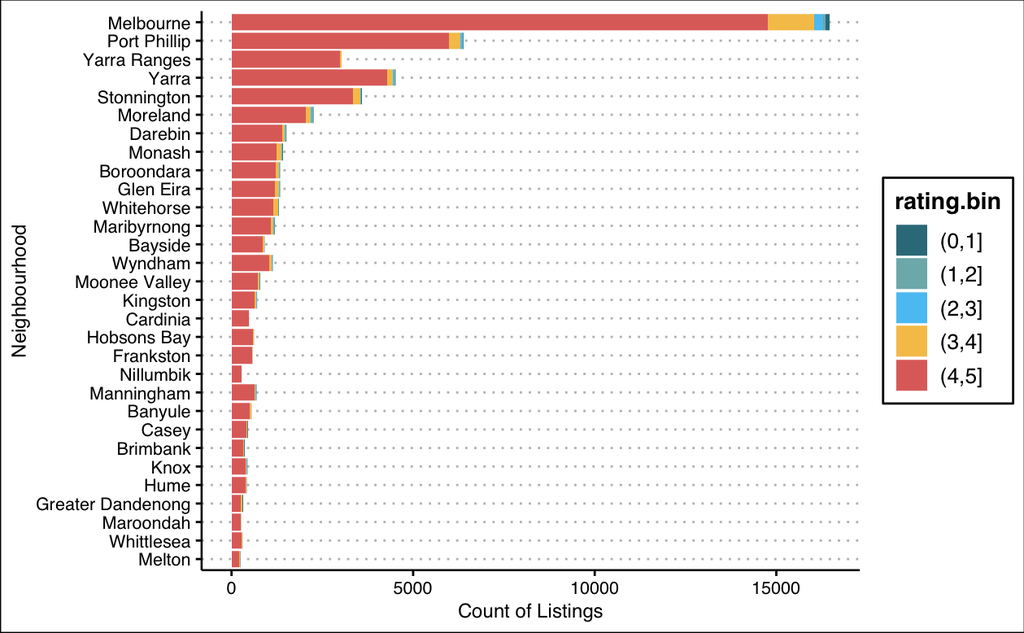

```r
#melbourne
ggplot(data = all.listings.final %>%
         group_by(nb_group,nb_cleansed,rating.bin) %>%
         filter(nb_group =="Melbourne") %>%
         filter(rating.bin!= "NA") %>%
         tally() %>%
         rename(total.listings = n),
       aes(x = reorder(nb_cleansed, total.listings), y = total.listings)) + geom_bar(mapping = aes(fill= rating.bin),stat="identity") +
  coord_flip() +
  labs(x="Neighbourhood", y="Count of Listings") +
  theme_clean() +
  scale_fill_manual("rating.bin", values=c("#357b8a", "#7db5b8", "#59c6f3", "#f6c458","#e06f69"))
```

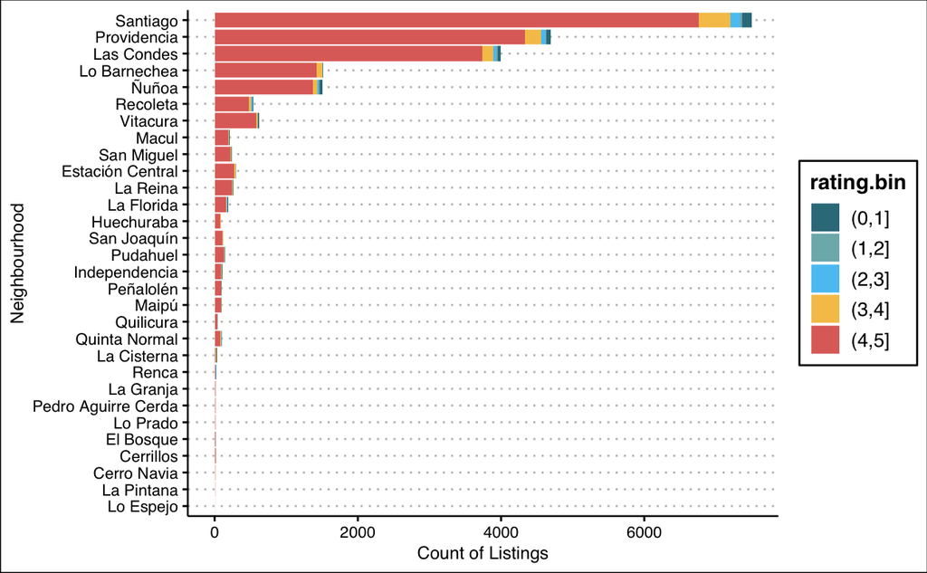

```r
#santiago
ggplot(data = all.listings.final %>%
         group_by(nb_group,nb_cleansed,rating.bin) %>%
         filter(nb_group =="Santiago") %>%
         filter(rating.bin!= "NA") %>%
         tally() %>%
         rename(total.listings = n),
       aes(x = reorder(nb_cleansed, total.listings), y = total.listings)) + geom_bar(mapping = aes(fill= rating.bin),stat="identity")+
  coord_flip() +
  labs(x="Neighbourhood", y="Count of Listings") +
  theme_clean() +
  scale_fill_manual("rating.bin", values=c("#357b8a", "#7db5b8", "#59c6f3", "#f6c458","#e06f69"))
```

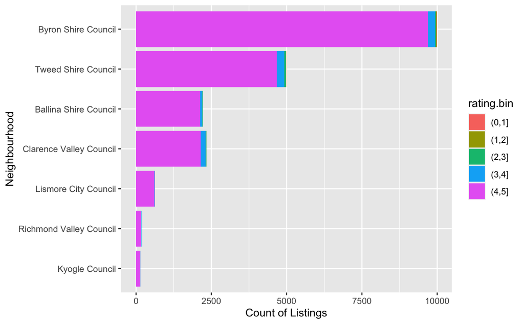

```r
#northern rivers
ggplot(data = all.listings.final %>%
         group_by(nb_group,nb_cleansed,rating.bin) %>%
         filter(nb_group =="Northern Rivers") %>%
         filter(rating.bin!= "NA") %>%
         tally() %>%
         rename(total.listings = n),
       aes(x = reorder(nb_cleansed, total.listings), y = total.listings)) + geom_bar(mapping = aes(fill= rating.bin),stat="identity") +
  coord_flip() +
  labs(x="Neighbourhood", y="Count of Listings")
```

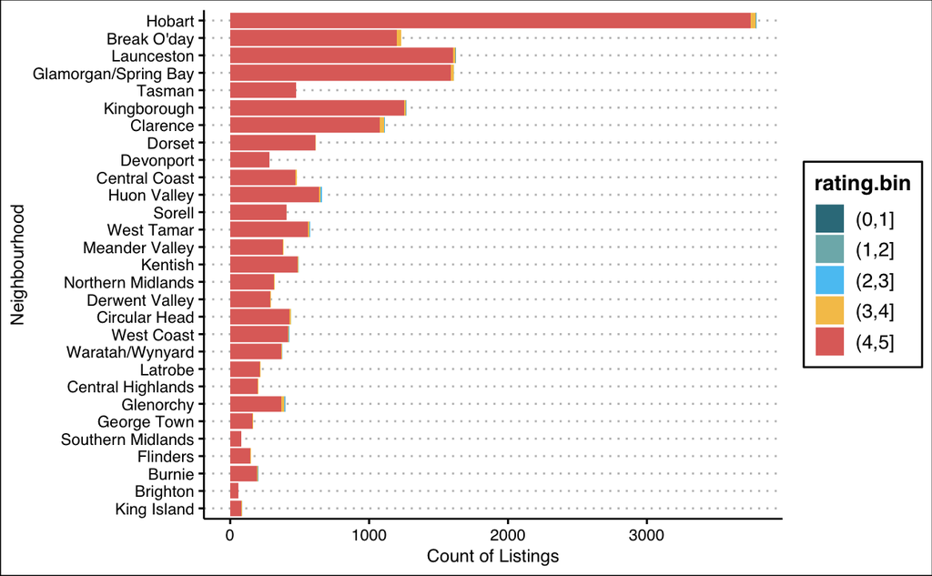

```r
ggplot(data = all.listings.final %>%
         group_by(nb_group,nb_cleansed,rating.bin) %>%
         filter(nb_group =="Tasmania") %>%
         filter(rating.bin!= "NA") %>%
         tally() %>%
         rename(total.listings = n),
       aes(x = reorder(nb_cleansed, total.listings), y = total.listings)) + geom_bar(mapping = aes(fill= rating.bin),stat="identity") +
  coord_flip() +
  labs(x="Neighbourhood", y="Count of Listings") +
  theme_clean()  +
  scale_fill_brewer(palette = "Dark2") +
  scale_fill_manual("rating.bin", values=c("#357b8a", "#7db5b8", "#59c6f3", "#f6c458","#e06f69"))
```

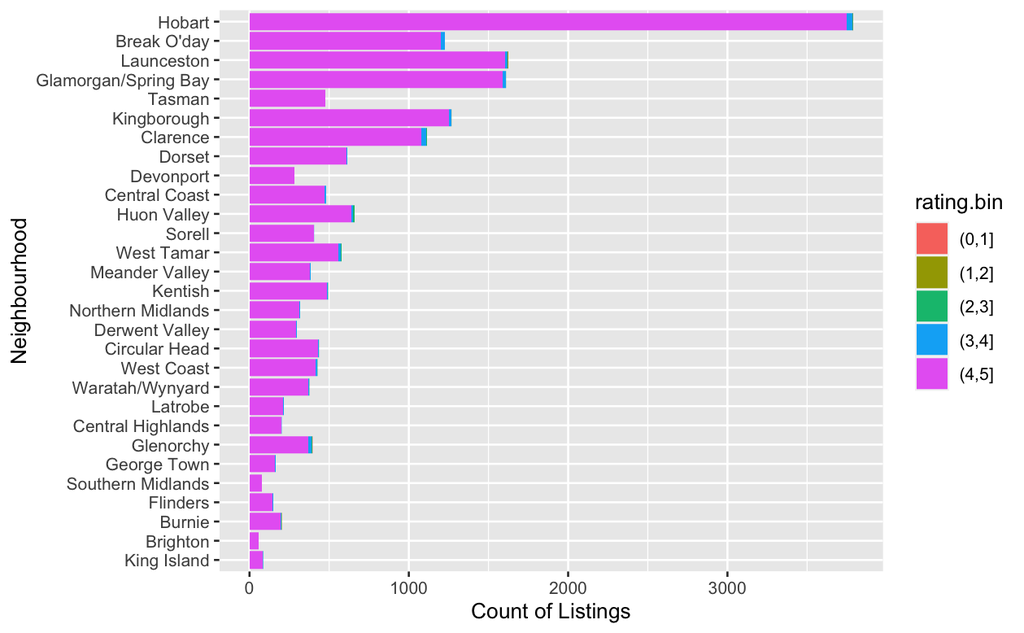

```r
# Tasmania
ggplot(data = all.listings.final %>%
         group_by(nb_group,nb_cleansed,rating.bin) %>%
         filter(nb_group =="Tasmania") %>%
         filter(rating.bin!= "NA") %>%
         tally() %>%
         rename(total.listings = n),
       aes(x = reorder(nb_cleansed, total.listings), y = total.listings)) + geom_bar(mapping = aes(fill= rating.bin),stat="identity") +
  coord_flip() +
  labs(x="Neighbourhood", y="Count of Listings")
```

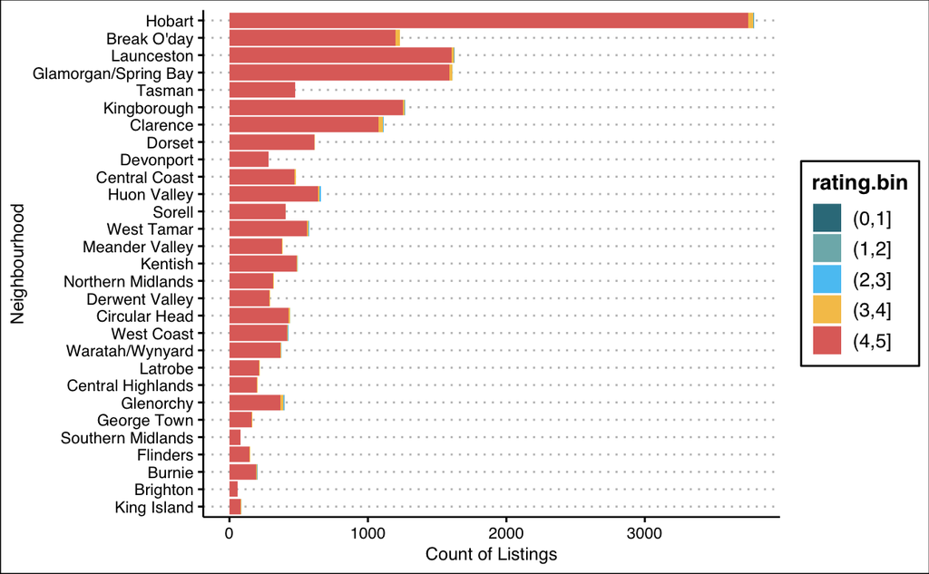

```r
ggplot(data = all.listings.final %>%
         group_by(nb_group,nb_cleansed,rating.bin) %>%
         filter(nb_group =="Tasmania") %>%
         filter(rating.bin!= "NA") %>%
         tally() %>%
         rename(total.listings = n),
       aes(x = reorder(nb_cleansed, total.listings), y = total.listings)) + geom_bar(mapping = aes(fill= rating.bin),stat="identity") +
  coord_flip() +
  labs(x="Neighbourhood", y="Count of Listings") +
  theme_clean()  +
  scale_fill_brewer(palette = "Dark2") +
  scale_fill_manual("rating.bin", values=c("#357b8a", "#7db5b8", "#59c6f3", "#f6c458","#e06f69"))
```

These plots point out that using average ratings as indication of preference won’t be very useful to segment preferences, as the large majority of Airbnb score their stays at 4-5 stars. Therefore, in the following visualizations we will focus on number of reviews instead.

Analysis of Reviews

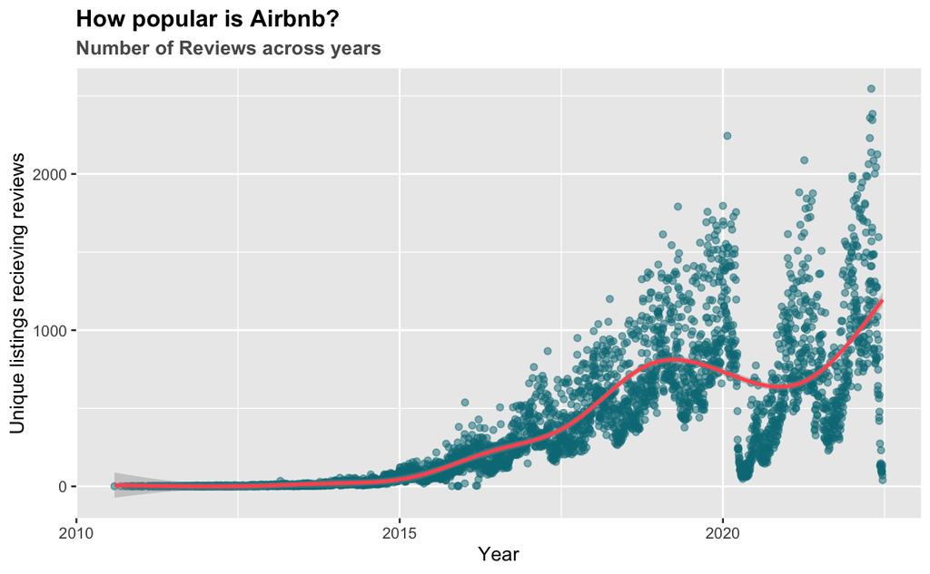

```r
reviewsNum <- all.reviews %>% group_by(date = all.reviews$date) %>% summarise(number = n())

ggplot(reviewsNum, aes(date, number)) +
           geom_point(na.rm=TRUE, color = "#007A87", alpha=0.5) +geom_smooth(color = "#FF5A5F")+
  ggtitle("How popular is Airbnb?",
          subtitle = "Number of Reviews across years") +
  labs(x = "Year", y = "Unique listings recieving reviews") +
  theme(plot.title = element_text(face = "bold")) +
  theme(plot.subtitle = element_text(face = "bold", color = "grey35")) +
  theme(plot.caption = element_text(color = "grey68"))
```

### 3.2 Bivariate Analysis

Firstly, we will use a scatter plot

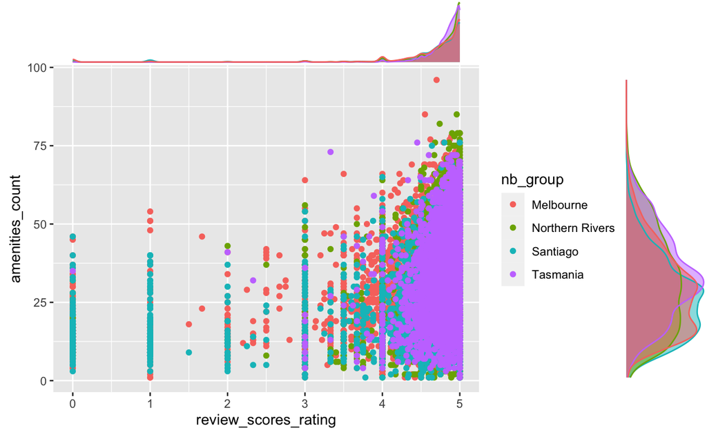

```r
scat1 <- ggplot(all.listings.final %>%
          filter(last_scraped.new=="Jun-2022") %>%
          select(nb_group,nb_cleansed,review_scores_rating,amenities_count, host_is_superhost),
             aes(review_scores_rating,amenities_count, colour = nb_group)) +
               geom_point()

scat2<- ggMarginal(scat1, groupColour = TRUE, groupFill = TRUE)
scat2
```

```r
#filter data to last quarter
#
scat3 <- ggplot(all.listings.final %>%
          filter(last_scraped.new=="Jun-2022") %>%
          filter(review_scores_rating>4) %>%
          select(nb_group,nb_cleansed,review_scores_rating,amenities_count, host_is_superhost),
             aes(review_scores_rating,amenities_count, colour = nb_group)) +
               geom_point()

scat4<- ggMarginal(scat3, groupColour = TRUE, groupFill = TRUE)
scat4
```

[output not shown]

### 3.3 Mapping

#### Melbourne

```r
# load melbourne map
mel.map <- st_read("data/Melbourne/2022_06/neighbourhoods.geojson", stringsAsFactors = FALSE)

# collapse dataframe and summarise price by neighbourhood
listing_summary <- all.listings.final %>%
  filter(last_scraped.new == "Jun-2022") %>%
  group_by(nb_group,nb_cleansed,last_scraped.new) %>%
  summarise(count = n(),
            avg_price = mean(price),
            min_price = min(price),
            max_price = max(price))

#correct listing summary fields

listing_summary$nb_cleansed <- as.character(listing_summary$nb_cleansed)
listing_summary <- listing_summary %>% rename(neighbourhood = nb_cleansed)

# combine summary and map
mel.map.data <- mel.map %>% inner_join(listing_summary)

#plot map
ggplot(mel.map.data) +
  geom_sf(aes(fill=avg_price)) +
  scale_fill_gradient(low = "#56B1F7", high ="#132B43") +
  geom_sf_text(aes(label=neighbourhood),color="white", check_overlap = TRUE)
```

[output not shown]

Bar plot based on neighborhood

```r
grouped.mel <- listings.mel %>%
  group_by(neighbourhood_cleansed,rating.bin) %>%
  tally() %>%
  rename(total.listings = n)
#plot it
ggplot(grouped.mel, aes(x = reorder(neighbourhood_cleansed, total.listings), y = total.listings)) + geom_bar(mapping = aes(fill= rating.bin),stat="identity") + coord_flip()
```

[output not shown]

#### Santiago

```r
# load melbourne map
scl.map <- st_read("data/Santiago/2022_06/neighbourhoods.geojson", stringsAsFactors = FALSE)

# collapse dataframe and summarise price by neighbourhood
listing_summary.scl <- all.listings.final %>%
  filter(last_scraped.new == "Jun-2022", nb_group == "Santiago") %>%
  group_by(nb_group,nb_cleansed,last_scraped.new) %>%
  summarise(count = n(),
            avg_price = mean(price),
            min_price = min(price),
            max_price = max(price))

#correct listing summary fields

listing_summarys.scl$nb_cleansed <- as.character(listing_summary$nb_cleansed)
listing_summary <- listing_summary %>% rename(neighbourhood = nb_cleansed)

# combine summary and map
mel.map.data <- mel.map %>% inner_join(listing_summary)

#plot map
ggplot(mel.map.data) +
  geom_sf(aes(fill=avg_price)) +
  scale_fill_gradient(low = "#56B1F7", high ="#132B43") +
  geom_sf_text(aes(label=neighbourhood),color="white", check_overlap = TRUE)
```

[output not shown]

```r
grouped.scl <- listings.scl %>%
  group_by(nb_cleansed,rating.bin) %>%
  tally() %>%
  rename(total.listings = n)
#plot it
ggplot(grouped.scl, aes(x = reorder(nb_cleansed, total.listings), y = total.listings)) + geom_bar(mapping = aes(fill= rating.bin),stat="identity") + coord_flip()
```

[output not shown]

#### Northern Rivers

```r
grouped.nr <- listings.nr %>%
  group_by(nb_cleansed,rating.bin) %>%
  tally() %>%
  rename(total.listings = n)
#plot it
ggplot(grouped.nr, aes(x = reorder(nb_cleansed, total.listings), y = total.listings)) + geom_bar(mapping = aes(fill= rating.bin),stat="identity") + coord_flip()
```

[output not shown]

#### Tasmania

```r
grouped.tas <- listings.tas %>%
  group_by(neighbourhood_cleansed,rating.bin) %>%
  tally() %>%
  rename(total.listings = n)
#plot it
ggplot(grouped.tas, aes(x = reorder(neighbourhood_cleansed, total.listings), y = total.listings)) + geom_bar(mapping = aes(fill= rating.bin),stat="identity") + coord_flip()
```

[output not shown]

**Popularity clusters (ggplot chorophlet of colored ratings)**

```r
#turn off sci notation.
options(scipen = 999)
# loading map geojson file
mel.map <- st_read("data/Melbourne/2022_06/neighbourhoods.geojson", stringsAsFactors = FALSE)
# create inner join of map and listings data
map.plus.listings.mel <- mel.map %>%
  inner_join(grouped.mel, by = c("neighbourhood" = "neighbourhood_cleansed"))
```

Perhaps prices are a good indicator of indicator of preference?

```r
#plot maps
ggplot(mel.map.data) +
  geom_sf(aes(fill=avg_price)) +
  scale_fill_gradient(low = "#56B1F7", high ="#132B43") +
  geom_sf_text(aes(label=neighbourhood),color="white", check_overlap = TRUE)
```

[output not shown]

```r
#
ggplot(scl.map.data) +
  geom_sf(aes(fill=avg_price)) +
  scale_fill_gradient(low = "#56B1F7", high ="#132B43") +
  geom_sf_text(aes(label=neighbourhood),color="white", check_overlap = TRUE)
```

[output not shown]

```r
ggplot(tas.map.data) +
  geom_sf(aes(fill=avg_price)) +
  scale_fill_gradient(low = "#56B1F7", high ="#132B43") +
  geom_sf_text(aes(label=neighbourhood),color="white", check_overlap = TRUE)
```

[output not shown]

```r
ggplot(nr.map.data) +
  geom_sf(aes(fill=avg_price)) +
  scale_fill_gradient(low = "#56B1F7", high ="#132B43") +
  geom_sf_text(aes(label=neighbourhood),color="white", check_overlap = TRUE)
```

[output not shown]

Hypothesis 1:

Popular listings in metropolitan cities are close to entertainment hubs (pubs and restaurants) and the CBD area. Smaller cities such as Hobart or Byron Bay present a similar pattern, but they also base their popularity on closeness to beaches and national parks.

Popular listings also rely on the type of amenities provided in the accommodation such as wi-fi, number of bathrooms, etc.

## References

[1] [Plot polygons from GeoJSON file to leaflet map](https://www.youtube.com/watch?v=hGzlvSIhvIc) (maps)

[2] [pw2/Data-Analysis-Framework: Step-by-step template for analysis/research projects (github.com)](https://github.com/pw2/Data-Analysis-Framework/tree/master) (report format)

[3] [How to clean the datasets in R? | R-bloggers](https://www.r-bloggers.com/2021/04/how-to-clean-the-datasets-in-r/) (data cleaning)

[4][Data Structures, Summaries, and Visualisations for Missing Data • naniar (njtierney.com)](https://naniar.njtierney.com/) (naniar)